# South Park Text Anlysis

Jinwook Chang

2022-04-16

This project may have contains *explicit language*.

South Park is a 25-year-old TV show that has aired since 1997 I don’t think it’s as popular as before. Many fans of the show say that the vitriol has become less so interesting of show is less than before I want to analyze this opinion is right, on this project.

## Load Libraries

```r
library(dplyr)
library(readr)
library(ggplot2)
library(tidymodels)
library(tidytext)
library(sweary) # devtools::install_github("pdrhlik/sweary")
```

## Load datasets

```r
sp_lines <- read_csv("sp_lines.csv")
sp_ratings <- read_csv("sp_ratings.csv")

tail(sp_lines)
```

| character | text | episode_name | season_number | episode_number |
| --- | --- | --- | --- | --- |
| officer bright | he broke free | Splatty Tomato | 21 | 10 |
| jimbo | the president is on the loose again | Splatty Tomato | 21 | 10 |
| officer bright | he’ll be even more desperate now it’s going to get worse | Splatty Tomato | 21 | 10 |
| stan | we can’t destroy him can we | Splatty Tomato | 21 | 10 |
| randy | i don’t know i guess it’s up to the whites | Splatty Tomato | 21 | 10 |
| end of splatty tomato | end of splatty tomato | Splatty Tomato | 21 | 10 |

```r
tail(sp_ratings)
```

| season_number | episode_number | rating | votes | episode_order |
| --- | --- | --- | --- | --- |
| 21 | 5 | 7.4 | 1091 | 282 |
| 21 | 6 | 7.3 | 964 | 283 |
| 21 | 7 | 7.4 | 1008 | 284 |
| 21 | 8 | 7.2 | 833 | 285 |
| 21 | 9 | 7.9 | 896 | 286 |
| 21 | 10 | 7.1 | 906 | 287 |

## Calculate Sentiment & Figure out swear words

```r
en_swear_words <- sweary::get_swearwords("en") %>%
    mutate(stem = SnowballC::wordStem(word))

afinn  <- read_csv("afinn.csv")


sp <- inner_join(sp_lines, sp_ratings)

sp_words <- sp %>%
    unnest_tokens(word, text) %>%
    anti_join(stop_words) %>%
    left_join(afinn) %>%
    mutate(word_stem = SnowballC::wordStem(word),
        swear_word = word %in% en_swear_words$word | word_stem %in% en_swear_words$stem)

# View the last six observations
tail(sp_words)
```

| character | episode_name | season_number | episode_number | rating | votes | episode_order | word | value | word_stem | swear_word |
| --- | --- | --- | --- | --- | --- | --- | --- | --- | --- | --- |
| officer bright | Splatty Tomato | 21 | 10 | 7.1 | 906 | 287 | worse | -3 | wors | FALSE |
| stan | Splatty Tomato | 21 | 10 | 7.1 | 906 | 287 | destroy | -3 | destroi | FALSE |
| randy | Splatty Tomato | 21 | 10 | 7.1 | 906 | 287 | guess | NA | guess | FALSE |
| randy | Splatty Tomato | 21 | 10 | 7.1 | 906 | 287 | whites | NA | white | FALSE |
| end of splatty tomato | Splatty Tomato | 21 | 10 | 7.1 | 906 | 287 | splatty | NA | splatti | FALSE |
| end of splatty tomato | Splatty Tomato | 21 | 10 | 7.1 | 906 | 287 | tomato | NA | tomato | FALSE |

## Summarize data by episode

```r
by_episode <- sp_words %>%
    group_by(episode_name, rating, episode_order) %>%
    summarize(
        swear_word_ratio = sum(swear_word) / n(),
        sentiment_score = mean(value, na.rm = TRUE)
    ) %>%
    arrange(episode_order)


tail(by_episode)
```

| episode_name | rating | episode_order | swear_word_ratio | sentiment_score |
| --- | --- | --- | --- | --- |
| Hummels & Heroin | 7.4 | 282 | 0.0213964 | -0.7567568 |
| Sons A Witches | 7.3 | 283 | 0.0092213 | -0.4285714 |
| Doubling Down | 7.4 | 284 | 0.0255840 | -0.7413793 |
| Moss Piglets | 7.2 | 285 | 0.0294643 | -0.1145833 |
| SUPER HARD PCness | 7.9 | 286 | 0.0139935 | -0.2562500 |
| Splatty Tomato | 7.1 | 287 | 0.0196592 | -0.5375000 |

```r
# What is the naughtiest episode?
( naughtiest <- by_episode[which.max(by_episode$swear_word_ratio), ] )
```

| episode_name | rating | episode_order | swear_word_ratio | sentiment_score |
| --- | --- | --- | --- | --- |
| It Hits the Fan | 8.5 | 66 | 0.1341557 | -1.978667 |

Below is the explantion for this episode on wikipedia : You can check how naughy is this episode :p

The episode was written by series co-creator Trey Parker and is rated TV-MA in the United States. Throughout the episode, the profanity “shit” or “shitty” are exclaimed uncensored a total of 162 separate times; in syndicated or re-aired versions of this episode, a counter in the bottom left corner of the screen counts the number of times the word has been uttered. The written occurrences are not counted, but “shit” is written 38 times, which brings the count up to an even 200. On a statistical average, the word “shit” is uttered roughly once for every eight seconds of showtime; one such count includes the episode’s theme song in the calculation.

## Overall Sentiment

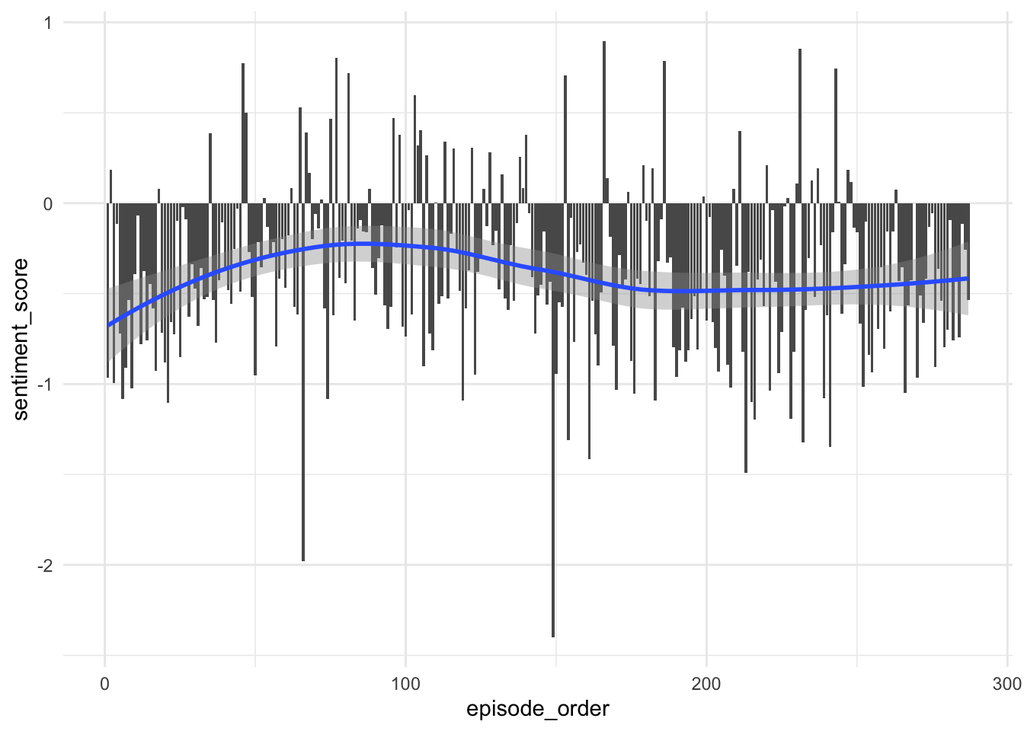

```r
theme_set(theme_minimal())

# Plot sentiment score for each episode
ggplot(by_episode, aes(episode_order, sentiment_score)) +
    geom_col() +
    geom_smooth()
```

## Overall Popularity

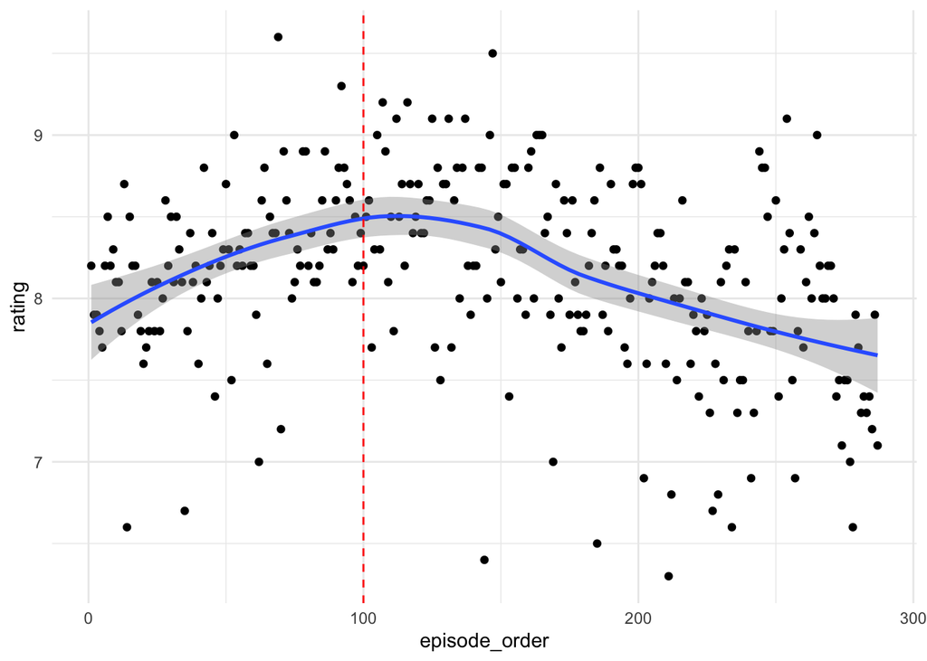

```r
ggplot(by_episode, aes(episode_order, rating)) +
    geom_point() +
    geom_smooth() +
    geom_vline(xintercept = 100, col = "red", lty = "dashed")
```

## More Naughty, More popular?

[figure not shown]

```r
ggplot(by_episode, aes(rating, swear_word_ratio)) +
    geom_point(alpha = 0.6, size = 3) +
    geom_smooth() +
    scale_y_continuous(labels = scales::percent) +
    scale_x_continuous(breaks = seq(6, 10, 0.5)) +
    labs(
        x = "IMDB rating",
        y = "Episode swear word ratio"
)
```

## Cluster Charcters by words

```r
characters <- c("butters", "cartman", "kenny", "kyle", "stan")

sp_lines <- sp_lines %>% filter(character %in% characters) %>% select(1, 2)
```

```python
import numpy as np
import pandas as pd
from sklearn.decomposition import NMF
from sklearn.feature_extraction.text import TfidfVectorizer

vect = TfidfVectorizer(min_df=50, stop_words='english')
X = vect.fit_transform(r.sp_lines.text)

model = NMF(n_components=5, random_state=46)
model.fit(X)
```

```
## NMF(n_components=5, random_state=46)
##
```

```python
nmf_features = model.transform(X)
```

```python
components_df = pd.DataFrame(model.components_, columns=vect.get_feature_names())
for topic in range(components_df.shape[0]):
    tmp = components_df.iloc[topic]
    print(f'For character {topic+1} the words with the highest value are:')
    print(tmp.nlargest(10))
    print('\n')
```

```
## For character 1 the words with the highest value are:
## yeah      6.199448
## think     0.089821
## like      0.086050
## cool      0.077808
## sure      0.076857
## guess     0.063402
## good      0.058217
## pretty    0.052270
## bad       0.048876
## really    0.048046
## Name: 0, dtype: float64
##
##
## For character 2 the words with the highest value are:
## oh        4.813204
## god       1.263572
## uh        0.482141
## jesus     0.233314
## kenny     0.189866
## killed    0.166331
## boy       0.162436
## man       0.125446
## huh       0.102252
## good      0.091829
## Name: 1, dtype: float64
##
##
## For character 3 the words with the highest value are:
## dude      4.081750
## whoa      0.136086
## fuck      0.107544
## hell      0.100296
## aw        0.099380
## ve        0.089987
## look      0.081388
## way       0.080232
## really    0.074801
## cool      0.074603
## Name: 2, dtype: float64
```

[output cut: 13 more lines]

```
## Name: 3, dtype: float64
##
##
## For character 5 the words with the highest value are:
## just       1.529826
## guys       1.260042
## hey        1.109871
## right      1.095260
## cartman    1.093989
## kyle       0.991578
## come       0.949527
## okay       0.766948
## gonna      0.733351
## let        0.630284
## Name: 4, dtype: float64
```

```python
pred_class = pd.DataFrame({'id' : [0, 1, 2, 3, 4], 'category' : ['1', '2', '3', '4', '5']})

train_pred = pd.DataFrame({'id':pd.DataFrame(nmf_features).idxmax(axis=1)})
train_pred.merge(pred_class, how = 'left', on = 'id').category
```

```
## 0        5
## 1        3
## 2        4
## 3        4
## 4        1
##         ..
## 29821    5
## 29822    5
## 29823    4
## 29824    5
## 29825    1
## Name: category, Length: 29826, dtype: object
```

```python
pred_result = train_pred.merge(pred_class, how = 'left', on = 'id').category.to_csv("pred_result.csv")
```

```r
pred_result <- read_csv("pred_result.csv")

sp_lines <- sp_lines %>% mutate(pred_result = pred_result$category)


table(sp_lines$character, sp_lines$pred_result)
```

```
##
##              1    2    3    4    5
##   butters  569  317   25  248 1700
##   cartman 1572  889  453  930 6784
##   kenny    354   61   60   45  409
##   kyle    1411  362  633  683 4378
##   stan    1484  440  857  670 4492
```

I’m quite sure character 3 is Eric :p  
because 3rd topics has word like `dude, fuck, hell`  
but it seems Stan uses more those words than Eric.